# Chapter 04 - fpp3

Leticia

2022-10-28

# Libraries

```r
library(fpp3)
library(GGally)
```

# Simple Stats

```r
tourism %>%
  features(Trips, list(mean = mean)) %>%
  arrange(mean)
```

```
## # A tibble: 304 x 4
##    Region          State              Purpose   mean
##    <chr>           <chr>              <chr>    <dbl>
##  1 Kangaroo Island South Australia    Other    0.340
##  2 MacDonnell      Northern Territory Other    0.449
##  3 Wilderness West Tasmania           Other    0.478
##  4 Barkly          Northern Territory Other    0.632
##  5 Clare Valley    South Australia    Other    0.898
##  6 Barossa         South Australia    Other    1.02
##  7 Kakadu Arnhem   Northern Territory Other    1.04
##  8 Lasseter        Northern Territory Other    1.14
##  9 Wimmera         Victoria           Other    1.15
## 10 MacDonnell      Northern Territory Visiting 1.18
## # ... with 294 more rows
```

```r
tourism %>% features(Trips, quantile)
```

```
## # A tibble: 304 x 8
##    Region         State             Purpose    `0%`  `25%`   `50%`  `75%` `100%`
##    <chr>          <chr>             <chr>     <dbl>  <dbl>   <dbl>  <dbl>  <dbl>
##  1 Adelaide       South Australia   Busine~  68.7   134.   153.    177.   242.
##  2 Adelaide       South Australia   Holiday 108.    135.   154.    172.   224.
##  3 Adelaide       South Australia   Other    25.9    43.9   53.8    62.5  107.
##  4 Adelaide       South Australia   Visiti~ 137.    179.   206.    229.   270.
##  5 Adelaide Hills South Australia   Busine~   0       0      1.26    3.92  28.6
##  6 Adelaide Hills South Australia   Holiday   0       5.77   8.52   14.1   35.8
##  7 Adelaide Hills South Australia   Other     0       0      0.908   2.09   8.95
##  8 Adelaide Hills South Australia   Visiti~   0.778   8.91  12.2    16.8   81.1
##  9 Alice Springs  Northern Territo~ Busine~   1.01    9.13  13.3    18.5   34.1
## 10 Alice Springs  Northern Territo~ Holiday   2.81   16.9   31.5    44.8   76.5
## # ... with 294 more rows
```

```r
tourism %>% features(Trips, feat_acf)
```

```
## # A tibble: 304 x 10
##    Region   State Purpose     acf1 acf10 diff1~1 diff1~2 diff2~3 diff2~4 seaso~5
##    <chr>    <chr> <chr>      <dbl> <dbl>   <dbl>   <dbl>   <dbl>   <dbl>   <dbl>
##  1 Adelaide Sout~ Busine~  0.0333  0.131  -0.520   0.463  -0.676   0.741  0.201
##  2 Adelaide Sout~ Holiday  0.0456  0.372  -0.343   0.614  -0.487   0.558  0.351
##  3 Adelaide Sout~ Other    0.517   1.15   -0.409   0.383  -0.675   0.792  0.342
##  4 Adelaide Sout~ Visiti~  0.0684  0.294  -0.394   0.452  -0.518   0.447  0.345
##  5 Adelaid~ Sout~ Busine~  0.0709  0.134  -0.580   0.415  -0.750   0.746 -0.0628
##  6 Adelaid~ Sout~ Holiday  0.131   0.313  -0.536   0.500  -0.716   0.906  0.208
##  7 Adelaid~ Sout~ Other    0.261   0.330  -0.253   0.317  -0.457   0.392  0.0745
##  8 Adelaid~ Sout~ Visiti~  0.139   0.117  -0.472   0.239  -0.626   0.408  0.170
##  9 Alice S~ Nort~ Busine~  0.217   0.367  -0.500   0.381  -0.658   0.587  0.315
## 10 Alice S~ Nort~ Holiday -0.00660 2.11   -0.153   2.11   -0.274   1.55   0.729
## # ... with 294 more rows, and abbreviated variable names 1: diff1_acf1,
## #   2: diff1_acf10, 3: diff2_acf1, 4: diff2_acf10, 5: season_acf1
```

# STL Features

FS (Seasonal Strength) close to 0 exhibits almost no seasonality, while a series with strong seasonality will have FS close to 1 because Var(Rt) will be much smaller than Var(St+Rt).

```r
tourism %>%
  features(Trips, feat_stl)
```

```
## # A tibble: 304 x 12
##    Region  State Purpose trend~1 seaso~2 seaso~3 seaso~4 spiki~5 linea~6 curva~7
##    <chr>   <chr> <chr>     <dbl>   <dbl>   <dbl>   <dbl>   <dbl>   <dbl>   <dbl>
##  1 Adelai~ Sout~ Busine~   0.464   0.407       3       1 1.58e+2  -5.31   71.6
##  2 Adelai~ Sout~ Holiday   0.554   0.619       1       2 9.17e+0  49.0    78.7
##  3 Adelai~ Sout~ Other     0.746   0.202       2       1 2.10e+0  95.1    43.4
##  4 Adelai~ Sout~ Visiti~   0.435   0.452       1       3 5.61e+1  34.6    71.4
##  5 Adelai~ Sout~ Busine~   0.464   0.179       3       0 1.03e-1   0.968  -3.22
##  6 Adelai~ Sout~ Holiday   0.528   0.296       2       1 1.77e-1  10.5    24.0
##  7 Adelai~ Sout~ Other     0.593   0.404       2       2 4.44e-4   4.28    3.19
##  8 Adelai~ Sout~ Visiti~   0.488   0.254       0       3 6.50e+0  34.2    -0.529
##  9 Alice ~ Nort~ Busine~   0.534   0.251       0       1 1.69e-1  23.8    19.5
## 10 Alice ~ Nort~ Holiday   0.381   0.832       3       1 7.39e-1 -19.6    10.5
## # ... with 294 more rows, 2 more variables: stl_e_acf1 <dbl>,
## #   stl_e_acf10 <dbl>, and abbreviated variable names 1: trend_strength,
## #   2: seasonal_strength_year, 3: seasonal_peak_year, 4: seasonal_trough_year,
## #   5: spikiness, 6: linearity, 7: curvature
```

# Plotting Seasonal Strength

Seasonal strength vs trend strength for all tourism series.

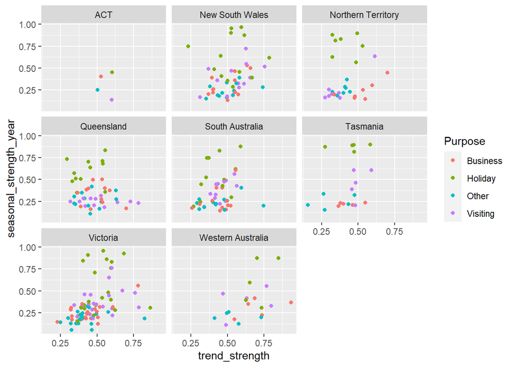

```r
tourism %>%
  features(Trips, feat_stl) %>%
  ggplot(aes(x = trend_strength, y = seasonal_strength_year,
             col = Purpose)) +
  geom_point() +
  facet_wrap(vars(State))
```

# The most seasonal series in the Australian tourism data

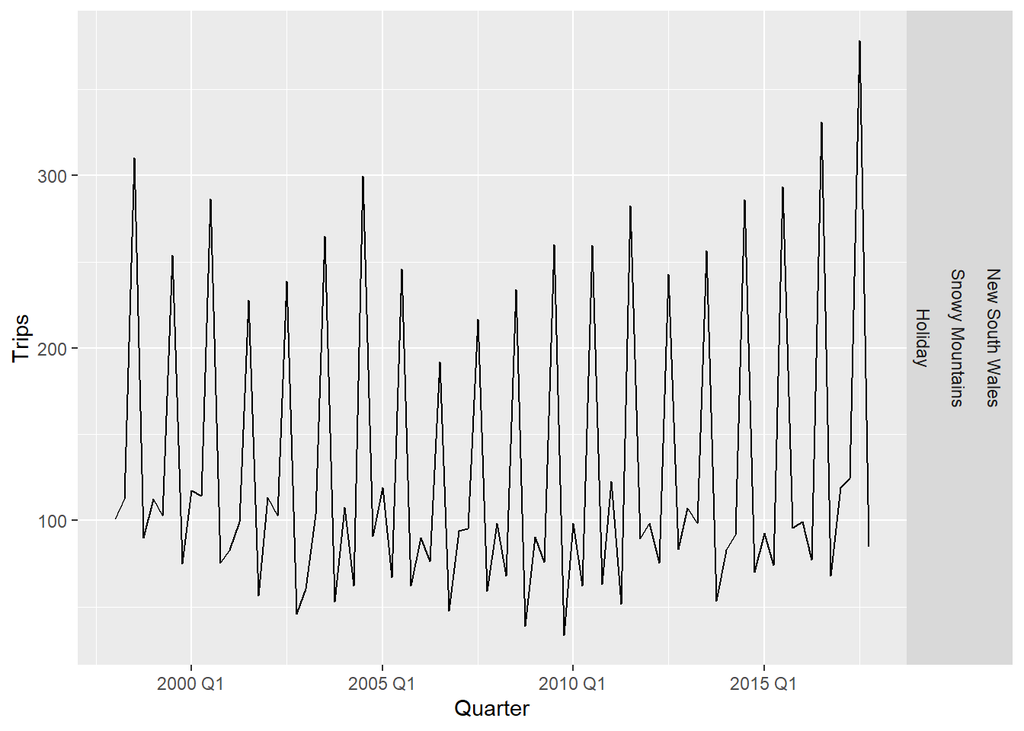

```r
tourism %>%
  features(Trips, feat_stl) %>%
  filter(
    seasonal_strength_year == max(seasonal_strength_year) #Filter here
  ) %>%
  left_join(tourism, by = c("State", "Region", "Purpose")) %>%
  ggplot(aes(x = Quarter, y = Trips)) +
  geom_line() +
  facet_grid(vars(State, Region, Purpose))
```

# All feasts features (48 features)

```r
tourism_features <- tourism %>%
  features(Trips, feature_set(pkgs = "feasts"))
tourism_features
```

```
## # A tibble: 304 x 51
##    Region  State Purpose trend~1 seaso~2 seaso~3 seaso~4 spiki~5 linea~6 curva~7
##    <chr>   <chr> <chr>     <dbl>   <dbl>   <dbl>   <dbl>   <dbl>   <dbl>   <dbl>
##  1 Adelai~ Sout~ Busine~   0.464   0.407       3       1 1.58e+2  -5.31   71.6
##  2 Adelai~ Sout~ Holiday   0.554   0.619       1       2 9.17e+0  49.0    78.7
##  3 Adelai~ Sout~ Other     0.746   0.202       2       1 2.10e+0  95.1    43.4
##  4 Adelai~ Sout~ Visiti~   0.435   0.452       1       3 5.61e+1  34.6    71.4
##  5 Adelai~ Sout~ Busine~   0.464   0.179       3       0 1.03e-1   0.968  -3.22
##  6 Adelai~ Sout~ Holiday   0.528   0.296       2       1 1.77e-1  10.5    24.0
##  7 Adelai~ Sout~ Other     0.593   0.404       2       2 4.44e-4   4.28    3.19
##  8 Adelai~ Sout~ Visiti~   0.488   0.254       0       3 6.50e+0  34.2    -0.529
##  9 Alice ~ Nort~ Busine~   0.534   0.251       0       1 1.69e-1  23.8    19.5
## 10 Alice ~ Nort~ Holiday   0.381   0.832       3       1 7.39e-1 -19.6    10.5
## # ... with 294 more rows, 41 more variables: stl_e_acf1 <dbl>,
## #   stl_e_acf10 <dbl>, acf1 <dbl>, acf10 <dbl>, diff1_acf1 <dbl>,
## #   diff1_acf10 <dbl>, diff2_acf1 <dbl>, diff2_acf10 <dbl>, season_acf1 <dbl>,
## #   pacf5 <dbl>, diff1_pacf5 <dbl>, diff2_pacf5 <dbl>, season_pacf <dbl>,
## #   zero_run_mean <dbl>, nonzero_squared_cv <dbl>, zero_start_prop <dbl>,
## #   zero_end_prop <dbl>, lambda_guerrero <dbl>, kpss_stat <dbl>,
## #   kpss_pvalue <dbl>, pp_stat <dbl>, pp_pvalue <dbl>, ndiffs <int>, ...
```

# Pairwise plots

Pairwise plots of all the seasonal features for the Australian tourism data

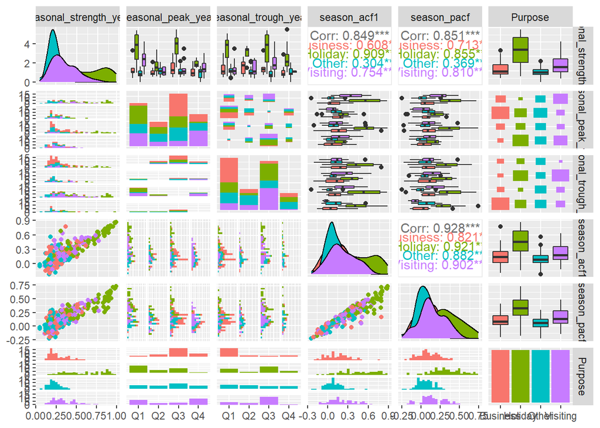

```r
library(glue)
tourism_features %>%
  select_at(vars(contains("season"), Purpose)) %>%
  mutate(
    seasonal_peak_year = seasonal_peak_year +
      4*(seasonal_peak_year==0),
    seasonal_trough_year = seasonal_trough_year +
      4*(seasonal_trough_year==0),
    seasonal_peak_year = glue("Q{seasonal_peak_year}"),
    seasonal_trough_year = glue("Q{seasonal_trough_year}"),
  ) %>%
  GGally::ggpairs(mapping = aes(colour = Purpose))
```

# Principal components of tourism

A plot of the first two principal components, calculated from the 48 features of the Australian quarterly tourism data.

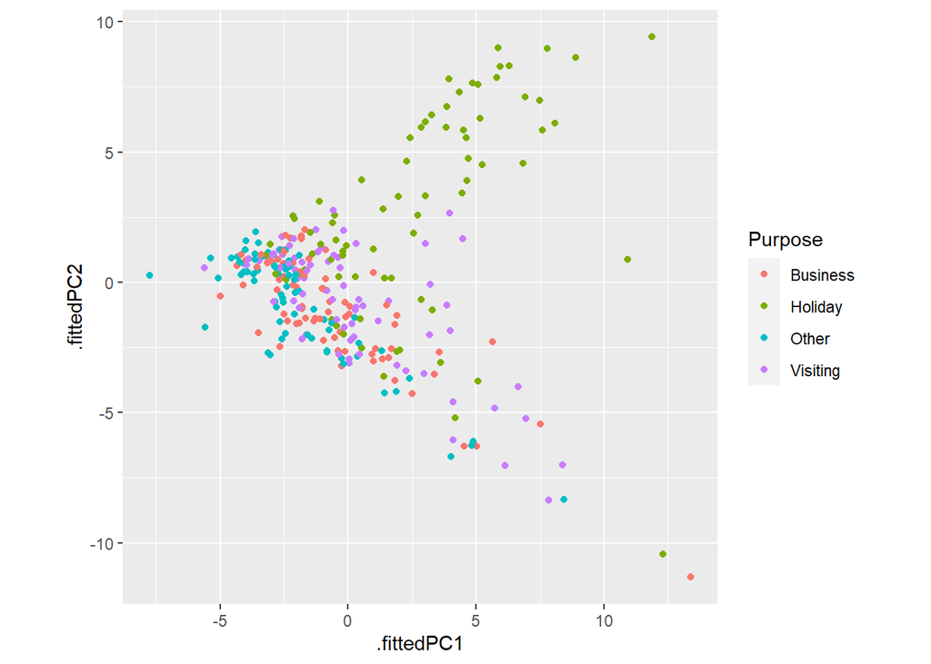

```r
library(broom)
pcs <- tourism_features %>%
  select(-State, -Region, -Purpose) %>%
  prcomp(scale = TRUE) %>%
  augment(tourism_features)
pcs %>%
  ggplot(aes(x = .fittedPC1, y = .fittedPC2, col = Purpose)) +
  geom_point() +
  theme(aspect.ratio = 1)
```

#Outliers

```r
outliers <- pcs %>%
  filter(.fittedPC1 > 10) %>%
  select(Region, State, Purpose, .fittedPC1, .fittedPC2)
outliers
```

```
## # A tibble: 4 x 5
##   Region                 State             Purpose  .fittedPC1 .fittedPC2
##   <chr>                  <chr>             <chr>         <dbl>      <dbl>
## 1 Australia's North West Western Australia Business       13.4    -11.3
## 2 Australia's South West Western Australia Holiday        10.9      0.880
## 3 Melbourne              Victoria          Holiday        12.3    -10.4
## 4 South Coast            New South Wales   Holiday        11.9      9.42
```

#Plot Outliers

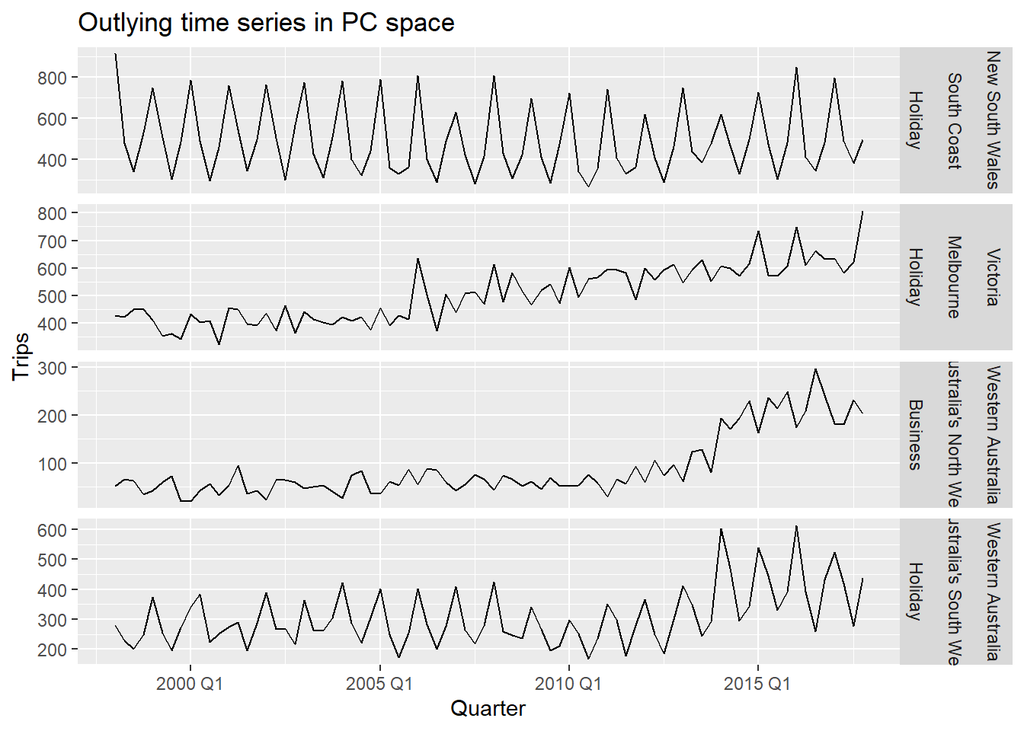

```r
outliers %>%
  left_join(tourism, by = c("State", "Region", "Purpose")) %>%
  mutate(
    Series = glue("{State}", "{Region}", "{Purpose}",
                  .sep = "\n\n")
  ) %>%
  ggplot(aes(x = Quarter, y = Trips)) +
  geom_line() +
  facet_grid(Series ~ ., scales = "free") +
  labs(title = "Outlying time series in PC space")
```

# Exercise

## 2

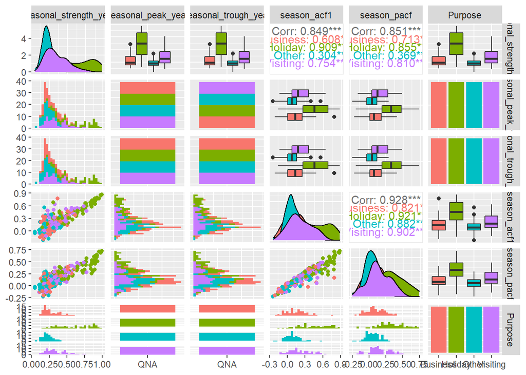

```r
library(glue)
tourism_features %>%
  select_at(vars(contains("season"), Purpose)) %>%
  mutate(seasonal_peak_year=as.factor(seasonal_peak_year)) %>%
  mutate(seasonal_trough_year=as.factor(seasonal_trough_year)) %>%
  mutate(
    seasonal_peak_year = seasonal_peak_year +
      4*(seasonal_peak_year==0),
    seasonal_trough_year = seasonal_trough_year +
      4*(seasonal_trough_year==0),
    seasonal_peak_year = glue("Q{seasonal_peak_year}"),
    seasonal_trough_year = glue("Q{seasonal_trough_year}"),
  ) %>%
  GGally::ggpairs(mapping = aes(colour = Purpose))
```

# Questions

- How to identify the years on line 41
- Hoe entropy and timeseries are related exactly? (lack of order or predictability; gradual decline into disorder)